# Analyse de la structure sociale du grand dauphin en Méditerranée nord-occidentale

Olivier Gimenez

August 12, 2016

## Introduction

Dans ce document, je fais une analyse des données de photo-identification du grand dauphin récoltées dans le cadre du projet [GDEGeM](http://www.gdegem.org/). Je me concentre ici sur les Golfe du Lion et Provence, et j’utilise le fichier `Matrice individus_Prov + GDL.xlsx` envoyé par email par Hélène (Labach) début novembre 2015.

## Préparation des données

On lit la feuille `Droite-Gauche` (7ème feuille) dans le fichier `Matrice individus_Prov + GDL.xlsx`. Au préalable, sous Excel, on supprime les colonnes qui contiennent les identifiants des différentes structures (je sais, pas très “reproducible research”…). On manipule ce fichier brut pour en extraire les ids, les dates et la matrice de détections/non-détections.

```r
# lecture des données
library(gdata)
#gecem = read.xls("Matrice individus_Prov + GDL.xlsx", sheet = 7, header = F,colClasses = "character")
#save(gecem,file='dat.RData')
setwd('/Users/gimenez/Dropbox/OG/BOULOT/GENS/Hélène LABACH/Gdegem/gedegem_la_suite')
load('dat.RData')
gecem <- gecem[,1:290]
#head(gecem)
```

On récupère les dates de sortie

```r
dates_temp <- gecem[1,]
dates <- dates_temp[,1]
for (i in 2:dim(dates_temp)[2]){
    dates <- c(dates,dates_temp[,i])
}
dates <- as.Date(dates,"%Y%m%d")
#dates
# on vérifie si certaines dates se retrouvent plusieurs fois
duplicated(dates)
```

```
##   [1] FALSE FALSE FALSE FALSE FALSE  TRUE FALSE FALSE FALSE FALSE FALSE
##  [12] FALSE FALSE  TRUE FALSE  TRUE  TRUE FALSE  TRUE FALSE FALSE FALSE
##  [23] FALSE FALSE FALSE FALSE FALSE FALSE FALSE FALSE FALSE FALSE FALSE
##  [34]  TRUE FALSE FALSE FALSE FALSE FALSE FALSE FALSE FALSE FALSE FALSE
##  [45] FALSE  TRUE FALSE FALSE FALSE  TRUE FALSE FALSE FALSE FALSE FALSE
##  [56] FALSE FALSE  TRUE FALSE FALSE  TRUE FALSE FALSE FALSE FALSE FALSE
##  [67]  TRUE FALSE FALSE FALSE  TRUE FALSE FALSE FALSE FALSE FALSE FALSE
##  [78] FALSE FALSE FALSE FALSE FALSE FALSE  TRUE FALSE FALSE  TRUE FALSE
##  [89] FALSE FALSE FALSE FALSE FALSE  TRUE FALSE  TRUE FALSE  TRUE FALSE
## [100] FALSE  TRUE FALSE FALSE FALSE FALSE  TRUE FALSE FALSE FALSE FALSE
## [111] FALSE FALSE FALSE FALSE FALSE  TRUE FALSE  TRUE FALSE FALSE FALSE
## [122] FALSE  TRUE FALSE FALSE FALSE FALSE  TRUE FALSE  TRUE  TRUE FALSE
## [133] FALSE FALSE FALSE  TRUE FALSE  TRUE FALSE FALSE FALSE  TRUE FALSE
## [144] FALSE FALSE  TRUE FALSE FALSE FALSE  TRUE FALSE FALSE FALSE  TRUE
## [155] FALSE  TRUE FALSE  TRUE  TRUE FALSE FALSE  TRUE FALSE FALSE FALSE
## [166]  TRUE FALSE FALSE FALSE FALSE FALSE  TRUE FALSE FALSE FALSE  TRUE
## [177] FALSE FALSE FALSE  TRUE FALSE FALSE  TRUE  TRUE FALSE  TRUE FALSE
## [188] FALSE  TRUE FALSE FALSE FALSE  TRUE  TRUE FALSE  TRUE  TRUE FALSE
## [199]  TRUE  TRUE FALSE  TRUE FALSE FALSE  TRUE FALSE FALSE FALSE FALSE
## [210] FALSE  TRUE FALSE FALSE FALSE FALSE  TRUE  TRUE FALSE FALSE FALSE
## [221] FALSE FALSE  TRUE FALSE  TRUE FALSE  TRUE FALSE FALSE FALSE  TRUE
## [232] FALSE  TRUE FALSE FALSE  TRUE FALSE  TRUE FALSE  TRUE FALSE FALSE
## [243]  TRUE  TRUE  TRUE FALSE FALSE FALSE FALSE  TRUE FALSE  TRUE FALSE
## [254]  TRUE FALSE  TRUE  TRUE FALSE FALSE  TRUE FALSE  TRUE FALSE  TRUE
## [265]  TRUE FALSE FALSE FALSE FALSE FALSE FALSE FALSE FALSE FALSE FALSE
## [276] FALSE  TRUE FALSE FALSE  TRUE FALSE FALSE FALSE  TRUE FALSE FALSE
## [287] FALSE FALSE FALSE FALSE
```

Dans le vecteur rendu par R, on a plusieurs ‘TRUE’ qui indique une date dupliquée. Je m’occuperai de ce problème plus bas.

On construit la matrice des détections/non-détections

```r
gecem <- gecem[-1,]
M <- gecem
M <- replace(M, M=="",0) # no capture
M <- replace(M, M=="g",1) # L
M <- replace(M, M=="d",1) # R
M <- replace(M, M=="dg", 1) # S
tp <- dim(M)
M <- as.matrix(M)
M <- matrix(as.numeric(M),nrow=tp[1],ncol=tp[2],byrow=F)
# il y avait des D, G et DG en majuscules,
# que j'ai passés en minuscules
# M
# Les dimensions de M sont :
tp
```

```
## [1] 928 290
```

On a donc 928 lignes, soit 928 individus identifiés individuellement, au cours de 290 occasions.

A ce stade, on voudrait appliquer un filtre en ne sélectionnant que les obs bien et moyennement marqués. On prendra un score inférieur ou égal 4, avec 2 et 2 au moins pour quality et distinctiveness (1 = meilleur, 3 = moins bon). Il nous faudra penser à garder en mémoire la proportion pour appliquer une correction afin d’obtenir la pop totale. Après discussion avec Hélène, le filtre s’avère un peu trop limitant. On refait les analyses en gardant l’observation si droite ou gauche est à 1 ou 2.

On commence par créer les 4 matrices qui regroupent les informations sur quality et distinctiveness

```r
#filtreQD = read.xls("Matrice individus_Prov + GDL.xlsx", sheet = 8, header = F,colClasses = "character")
#filtreQG = read.xls("Matrice individus_Prov + GDL.xlsx", sheet = 9, header = F,colClasses = "character")
#filtreDD = read.xls("Matrice individus_Prov + GDL.xlsx", sheet = 10, header = F,colClasses = "character")
#filtreDG = read.xls("Matrice individus_Prov + GDL.xlsx", sheet = 11, header = F,colClasses = "character")
#save(filtreQD,filtreQG,filtreDD,filtreDG,file='filtre.RData')
load('filtre.RData')

# quality droite
filtre <- filtreQD[-1,]
filtre <- filtre[,-1]
filtre <- replace(filtre, filtre=="",0) # no capture
dimfiltre <- dim(filtre)
filtre <- as.matrix(filtre)
filtre <- matrix(as.numeric(filtre),nrow=dimfiltre[1],ncol=dimfiltre[2],byrow=F)
filtre[is.na(filtre)]<-0 # il y a des caractères bizarres qui se sont introduits, dans des cellules vides, je les remplace par des 0 (après avoir fait qqs vérif)
QD <- filtre

# quality gauche
filtre <- filtreQG[-1,]
filtre <- filtre[,-1]
filtre <- replace(filtre, filtre=="",0) # no capture
dimfiltre <- dim(filtre)
filtre <- as.matrix(filtre)
filtre <- matrix(as.numeric(filtre),nrow=dimfiltre[1],ncol=dimfiltre[2],byrow=F)
filtre[is.na(filtre)]<-0 # il y a des caractères bizarres qui se sont introduits, dans des cellules vides, je les remplace par des 0 (après avoir fait qqs vérif)
QG <- filtre

# distinctiveness droite
filtre <- filtreDD[-1,]
filtre <- filtre[,-1]
filtre <- replace(filtre, filtre=="",0) # no capture
dimfiltre <- dim(filtre)
filtre <- as.matrix(filtre)
filtre <- matrix(as.numeric(filtre),nrow=dimfiltre[1],ncol=dimfiltre[2],byrow=F)
filtre[is.na(filtre)]<-0 # il y a des caractères bizarres qui se sont introduits, dans des cellules vides, je les remplace par des 0 (après avoir fait qqs vérif)
DD <- filtre

# distinctiveness gauche
filtre <- filtreDG[-1,]
filtre <- filtre[,-1]
filtre <- replace(filtre, filtre=="",0) # no capture
dimfiltre <- dim(filtre)
filtre <- as.matrix(filtre)
filtre <- matrix(as.numeric(filtre),nrow=dimfiltre[1],ncol=dimfiltre[2],byrow=F)
filtre[is.na(filtre)]<-0 # il y a des caractères bizarres qui se sont introduits, dans des cellules vides, je les remplace par des 0 (après avoir fait qqs vérif)
DG <- filtre
```

On applique le filtre défini ci-dessus, et on crée deux matrices qui sont la somme des gauche et droite.

```r
QG[QG == 3] = 0
QD[QD == 3] = 0
DG[DG == 3] = 0
DD[DD == 3] = 0
qualite <- QG + QD
distinc <- DG + DD
```

On réunit alors les deux matrices pour avoir la note globale. Puis on crée la nouvelle matrice d’observations :

```r
selection <- qualite + distinc
Mselect <- selection
Mselect[Mselect>=1]=1
dim(Mselect)
```

```
## [1] 928 290
```

Parmi ces 290 occasions, on retrouve plusieurs dates dupliquées :

```r
dates[duplicated(dates)]
```

```
##  [1] "2013-05-27" "2013-06-04" "2013-06-05" "2013-06-05" "2013-06-06"
##  [6] "2013-07-18" "2013-09-08" "2013-09-14" "2013-10-07" "2013-10-09"
## [11] "2013-10-15" "2013-10-18" "2014-01-12" "2014-02-13" "2014-03-07"
## [16] "2014-03-08" "2014-03-10" "2014-03-13" "2014-03-18" "2014-05-07"
## [21] "2014-05-17" "2014-06-04" "2014-06-11" "2014-06-12" "2014-06-12"
## [26] "2014-06-16" "2014-06-17" "2014-06-20" "2014-06-28" "2014-07-16"
## [31] "2014-07-24" "2014-07-25" "2014-08-01" "2014-08-01" "2014-08-04"
## [36] "2014-08-07" "2014-08-12" "2014-08-18" "2014-08-21" "2014-08-25"
## [41] "2014-08-25" "2014-08-26" "2014-08-28" "2014-09-08" "2014-09-08"
## [46] "2014-09-09" "2014-09-09" "2014-09-10" "2014-09-10" "2014-09-11"
## [51] "2014-09-13" "2014-09-21" "2014-10-20" "2014-10-20" "2014-10-25"
## [56] "2014-10-26" "2014-10-27" "2014-10-30" "2014-10-31" "2014-11-16"
## [61] "2014-11-19" "2014-12-04" "2014-12-22" "2014-12-22" "2014-12-22"
## [66] "2015-02-12" "2015-02-13" "2015-02-14" "2015-02-15" "2015-02-15"
## [71] "2015-02-18" "2015-02-19" "2015-02-20" "2015-02-20" "2015-03-06"
## [76] "2015-03-08" "2015-03-14"
```

Je regroupe ces observations sous une seule occasion dans M (en vérifiant bien qu’un même individu n’est pas vu à ces deux occasions), et je supprime le duplicat dans le vecteur des dates ; je fais ça autant de fois qu’il y a de duplicats :

```r
Mselectdf <- data.frame(dates=dates,Mselect=t(Mselect))
library(plyr)
Mselect2 <- ddply(Mselectdf,"dates",numcolwise(max))
Mselect <- t(Mselect2)
Mselect <- Mselect[-1,]
dim(Mselect)
```

```
## [1] 928 213
```

```r
Mselect <- matrix(as.numeric(Mselect),nrow=dim(Mselect)[1],ncol=dim(Mselect)[2],byrow=F)
```

On fait subir le même traitement à M :

```r
Mdf <- data.frame(dates=dates,M=t(M))
library(plyr)
M2 <- ddply(Mdf,"dates",numcolwise(max))
M <- t(M2)
M <- M[-1,]
dim(M)
```

```
## [1] 928 213
```

```r
indic <- (1:tp[2])[duplicated(dates)]
dates <- dates[-indic]
length(dates)
```

```
## [1] 213
```

```r
tp <- dim(M)
tp
```

```
## [1] 928 213
```

```r
M <- matrix(as.numeric(M),nrow=tp[1],ncol=tp[2],byrow=F)
```

Calcule le nombre d’individus vus au moins 1 fois, 2 fois, 3 fois etc…

```r
sum(apply(Mselect,1,sum)>0)
```

```
## [1] 635
```

```r
sum(apply(Mselect,1,sum)>1)
```

```
## [1] 181
```

```r
sum(apply(Mselect,1,sum)>2)
```

```
## [1] 67
```

```r
sum(apply(Mselect,1,sum)>3)
```

```
## [1] 28
```

```r
sum(apply(M,1,sum)>0)
```

```
## [1] 928
```

```r
sum(apply(M,1,sum)>1)
```

```
## [1] 306
```

```r
sum(apply(M,1,sum)>2)
```

```
## [1] 159
```

```r
sum(apply(M,1,sum)>3)
```

```
## [1] 73
```

Il nous faut maintenant assigner ces individus à des groupes. Pour ce faire, on utilise la feuille des observations :

```r
library(gdata)
#obs_gecem = read.xls("Matrice individus_Prov + GDL.xlsx", sheet = 2, header = F,colClasses = "character")
#save(obs_gecem,file='obs.RData')
load('obs.RData')
```

On se débarrasse des 3 dernières colonnes qui donnent des stats descriptives diverses :

```r
obs_gecem <- obs_gecem[,2:290]
obs_gecem <- obs_gecem[-1,] # on supprime les dates
obs_gecem <- replace(obs_gecem, obs_gecem =="",0) # no capture
dim(obs_gecem)
```

```
## [1] 930 289
```

```r
obs_gecem2 <- obs_gecem[(apply(M,1,sum)>2),]
dim(obs_gecem2)
```

```
## [1] 161 289
```

```r
# recupere le nom des groupes
groups <- levels(factor(unlist(obs_gecem2)))[-1]
#groups
```

## Analyse de la structure sociale

Je cherche à créer un tableau avec en lignes ces groupes, et en colonne les individus puis dans les cellules des 1 quand l’individu est dans le groupe, et des 0 sinon :

```r
nbindiv <- dim(obs_gecem2)[1]
nbgroups <- length(groups)
network_dolphin <- matrix(0,nrow=nbgroups,ncol=nbindiv)
vect_ind <- 1:nbindiv
for (i in 1: nbgroups){
    mask <- (obs_gecem2==groups[i]) # ou sont les individus du groupe courant
    mask2 <- apply(mask,1,sum)!=0 # quels sont les individus du groupe courant
    interaction <- vect_ind[mask2]
    network_dolphin[i,interaction] <- 1 # met un 1 pour indiquer l'interaction
}

colnames(network_dolphin) <- rownames(obs_gecem2)
rownames(network_dolphin) <- groups

str(network_dolphin)
```

```
##  num [1:419, 1:161] 0 0 0 0 0 0 1 1 0 0 ...
##  - attr(*, "dimnames")=List of 2
##   ..$ : chr [1:419] "130508_BR_SSO001" "130527_GC_STP001" "130527_GC_STP002" "130528_GC_STP003" ...
##   ..$ : chr [1:161] "2" "3" "7" "8" ...
```

Lit les données et charge le package qui va bien :

```r
library(asnipe)
#data_pop_struct <- as.matrix(data_pop_struct)
dim(network_dolphin)
```

```
## [1] 419 161
```

```r
#dimnames(network_dolphin)
network<-get_network(network_dolphin,data_format= "GBI", association_index="HWI")
```

```
## Generating  161  x  161  matrix
```

Construit le réseau :

```r
library(igraph)
net<-graph.adjacency(network,mode='undirected',diag=FALSE,weighted=TRUE)
```

On clusterise. Attention, on a 7 groupes avec les 161 individus vs. les 4 groupes trouvés avec seulement 68 individus :

```r
fc <- cluster_fast_greedy(net)
comps = fc$membership
colbar <- rainbow(max(comps)+1) # on rajoute les couleurs de l'arc-en-ciel - moment poésie...
V(net)$color <- colbar[comps+1]

#comps[comps==1]<-'red'
#comps[comps==2]<-'steelblue1'
#comps[comps==3]<-'green'
#comps[comps==4]<-'yellow'
#V(net)$color <- comps
```

Tadannnn, le réseau social, enfin :

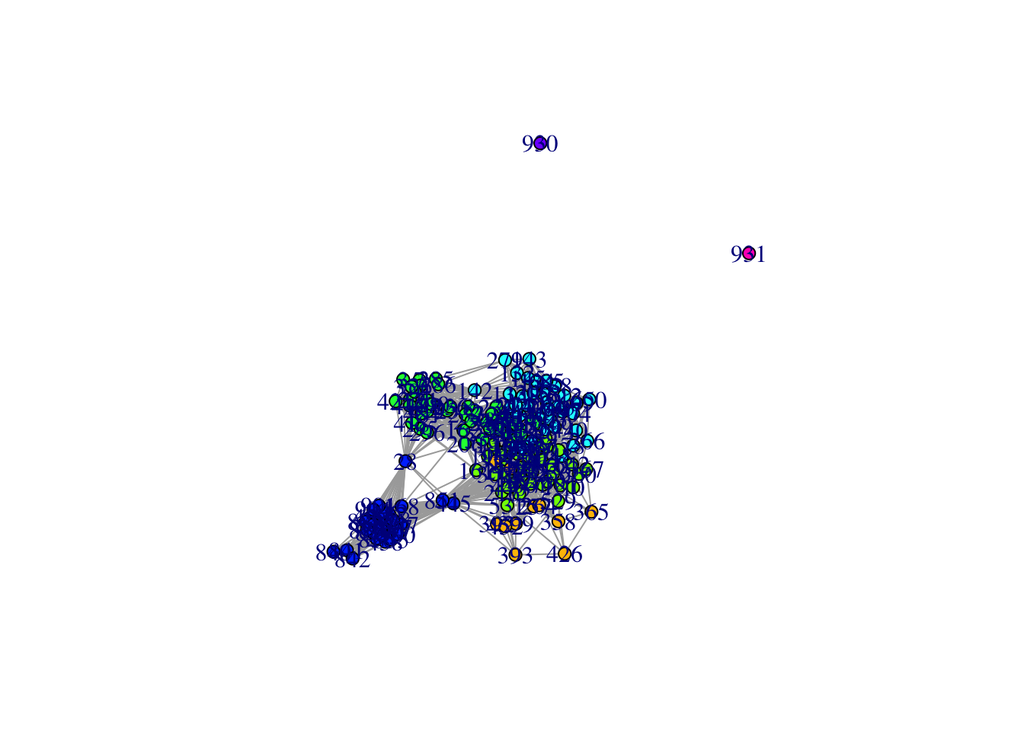

```r
plot(net,vertex.size=6)
```

Moins glamour, le dendrogramme (vérifier que les couleurs correspondent à celle utilisées pour représenter graphiquement le réseau social) :

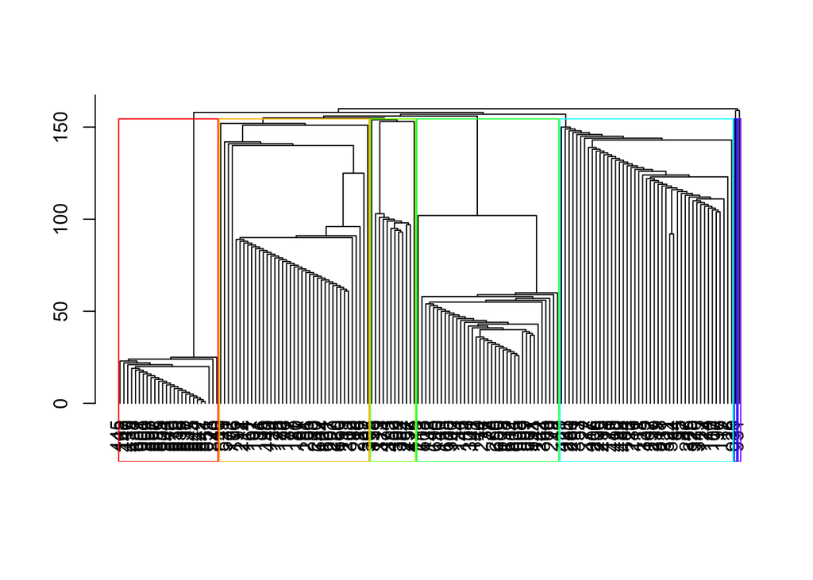

```r
plot_dendrogram(fc,mode = "hclust",colbar=colbar)
```

On teste si les individus s’associe préférentiellement de manière significative :

```r
library(sna)
library(asnipe)
# Calculate network
networks <- get_network(network_dolphin, data_format="GBI", association_index="HWI")
```

```
## Generating  161  x  161  matrix
```

```r
deg_weighted <- degree(networks,gmode="graph", ignore.eval=FALSE)

# Perform the permutations
network_perm <- network_permutation(network_dolphin, data_format="GBI", association_matrix=networks, permutations = 1000)
```

```
## Starting permutations, generating  1000  x  161  x  161  matrix
```

```r
dim(network_perm)
```

```
## [1] 1000  161  161
```

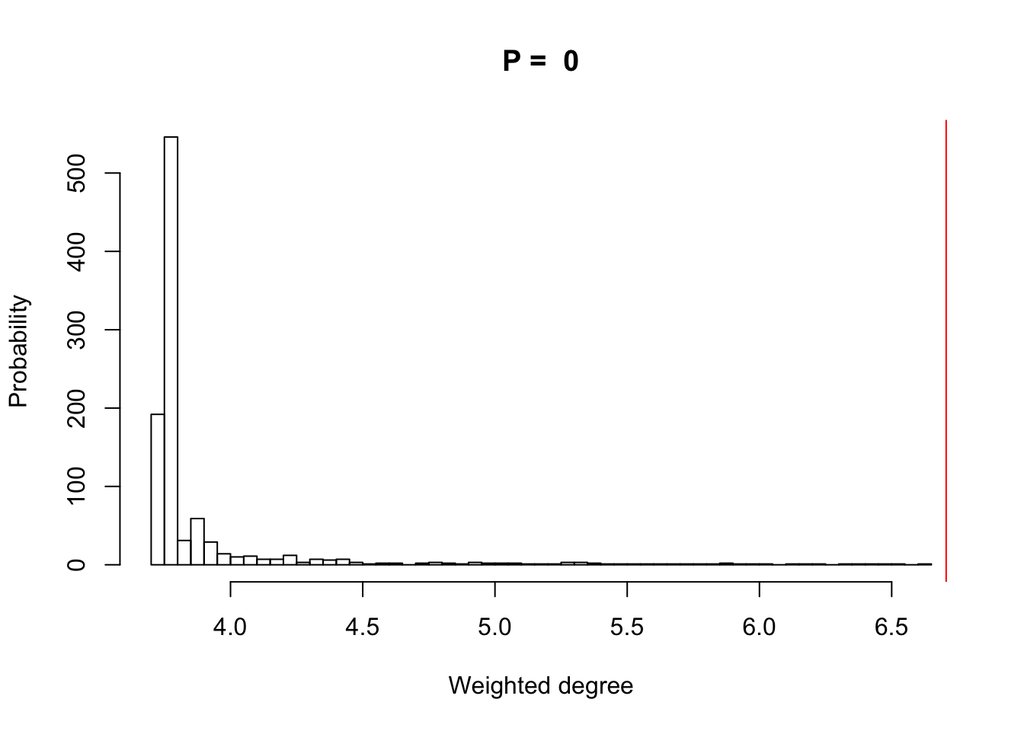

```r
# Calculate the weighted degree for each permutation
deg_weighted_perm <- degree(network_perm,gmode="graph", g=c(1:1000), ignore.eval=FALSE)

# Plot the distribution of permutations with the original data overlaid
hist(colMeans(deg_weighted_perm),breaks=100,
     main=paste("P = ",sum(mean(deg_weighted) < colMeans(deg_weighted_perm))/ncol(deg_weighted_perm)),
     xlab="Weighted degree", ylab="Probability")
abline(v=mean(deg_weighted), col="red")
```

Si on utilise SD(HWI) à la place de HWI :

```r
networks <- get_network(network_dolphin, data_format="GBI", association_index="HWI")
```

```
## Generating  161  x  161  matrix
```

```r
networks_sd <- sd(networks)

network_perm <- network_permutation(network_dolphin, data_format="GBI", association_matrix=networks, permutations = 1000)
```

```
## Starting permutations, generating  1000  x  161  x  161  matrix
```

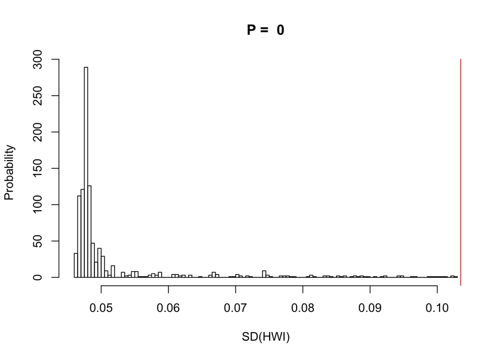

```r
nb.permut <- dim(network_perm)[1]
network_perm_sd <- rep(NA, nb.permut)
for(i in 1 : nb.permut){network_perm_sd[i] <- sd(network_perm[i,,])}

hist(network_perm_sd,breaks=100,main=paste("P = ",sum(networks_sd < network_perm_sd) / nb.permut),xlab="SD(HWI)", ylab="Probability")
abline(v=networks_sd, col="red")
```